# Herramientas de visualización de datos

## Introducción

La visualización de datos es una parte imprescindible en la minería de datos. Lo primero que hacemos cuando nos enfrentamos a un nuevo conjunto de datos es el análisis exploratorio que nos permite conocer mejor nuestros datos. En esta fase, ser capaces de crear visualizaciones ayuda notablemente a entender la estructura y ver más claras las relaciones entre las variables, sobretodo cuando nos enfrentamos a *datasets* grandes o con una alta dimensionalidad.

Podemos ver el análisis visual de los datos incluido en un proceso contínuo de *feedback* entre la visualización y la construcción de modelos estadísticos, como nos propone Keim (diagrama). Un modelo estadístico más adecuado nos permite crear mejores visualizaciones que a la vez, nos darán pistas para construir modelos más complejos y detallados.

[figure not shown]

En esta actividad presentaremos algunas de las librerías más usadas en `Python` para generar visualizaciones y mostraremos ejemplos de cómo generar los gráficos más habituales.

## Librerías de visualización de datos

### Matplotlib

[`Matplotlib`](https://matplotlib.org/) es la librería de visualización de datos más popular, y permite crear visualizaciones de una forma bastante fácil.

[figure not shown]

### Seaborn

[`Seaborn`](https://seaborn.pydata.org/) es una librería basada en `Matplotlib` que está enfocada en la visualización de modelos estadíticos. `Seaborn` no pretende substituir `Matplotlib`, sinó complementarla para poder hacer visualizaciones más complejas con una programación de alto nivel y con menos esfuerzo.

[figure not shown]

### Bokeh

[`Bokeh`](https://bokeh.pydata.org/en/latest/) es otra librería de visualización de datos enfocada a las visualizaciones interactivas. A diferencia de `Seaborn`, `Bokeh` és independiente de `Matplotlib`. El principal foco de `Bokeh` es la interacción en el web en el estilo de los documentos centrados en datos [D3.js Data-Driven Documents](https://d3js.org/).

[figure not shown]

## *House prices dataset*

El conjunto de datos que usaremos en esta actividad corresponde al *dataset* [House Prices: Advanced Regression Techniques](https://www.kaggle.com/c/house-prices-advanced-regression-techniques) que es una de las competiciones de iniciación de Kaggle.

```python
import numpy as np
import pandas as pd

import seaborn as sns
import matplotlib.pyplot as plt

df_train = pd.read_csv('data/train.csv')
```

## Visualizaciones más comunes

A continuación veremos algunas de les visualizaciones más comunes y cómo implementarlas en alguna de las tres librerías que hemos presentado antes.

### Diagrama de barras

El diagrama de barras es una de las visualizaciones más comunes. Nos muestra la relación entre una variable numérica y otra de categórica. Por ejemplo, podemos mostrar la relación entre el número de baños de una vivenda y el precio de venda medio.

En este ejemplo, primero calcularemos el precio medio de venta por número de baños y después usaremos la función `plot` de `Matplotlib` para visualizarla.

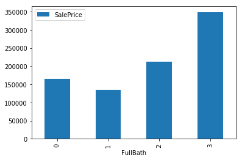

```python
pivot = df_train.pivot_table(index='FullBath', values='SalePrice', aggfunc=np.mean)
pivot.plot(kind='bar')
```

### Histograma y diagrama de densidad

#### Histograma

Un histograma nos permite representar gráficamente la distribución de una variable numérica. La variable se divide en diferentes particiones o *bins* que representan un rango de valores de la variable. Para cada partición se representa el número de observaciones en aquel rango de valores. La forma del histograma puede canviar considerablemente dependiendo del número de particiones que definamos.

A continuación mostraremos la distribución de la variable `SalePrice` con diferentes números de particiones. Usaremos la función `distplot` de la librería `Seaborn`.

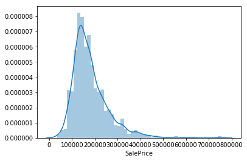

```python
sns.distplot(df_train["SalePrice"])
```

Canviamos el nombre de particiones a 100:

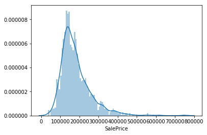

```python
sns.distplot(df_train["SalePrice"], bins=100)
```

Y ahora con sólo 10:

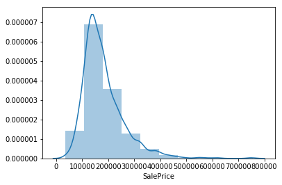

```python
sns.distplot(df_train["SalePrice"], bins=10)
```

#### Diagrama de densidad

El diagrama de densidad también muestra la distribución de una variable numérica, y es muy parecido al histograma. El diagrama de densidad es una curva que suaviza la discontinuidad de las particiones del histograma y tiene un parámetre *bandwidth* (`bw`) para controlar de qué manera se adapta a los datos.

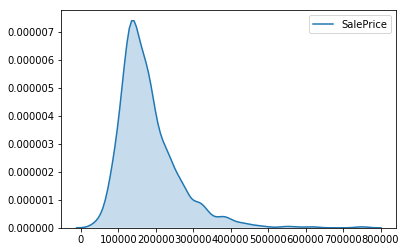

```python
sns.kdeplot(df_train["SalePrice"], shade=True)
```

El valor per defecto intenta hacer una buena adaptación pero puede ser útil probar otros valores.

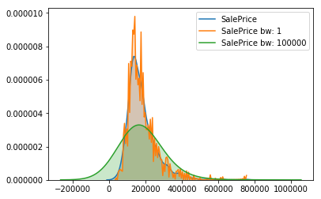

```python
sns.kdeplot(df_train["SalePrice"], shade=True)
sns.kdeplot(df_train["SalePrice"], shade=True, bw=1, label="SalePrice bw: 1")
sns.kdeplot(df_train["SalePrice"], shade=True, bw=100000, label="SalePrice bw: 100000")
plt.legend();
```

### Diagrama de cajas y de violín

El diagrama de cajas nos da un sumario gráfico de una o varias variables. La línia que divide la caja en dos mitades representa el valor de la mediana de los datos. Los extremos de la caja muestras los cuartiles inferiores y superiores y las línias extremas los valores máximos y mínimos excluyendo los *outliers*. El diagrama de cajas pero, esconde parte de la información, como la distribución de los valores de la variable o el número de observaciones.

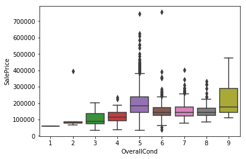

```python
sns.boxplot(x=df_train["OverallCond"], y=df_train["SalePrice"])
```

Podemos añadirle el detalle de las observaciones o *jitter* con la función `swarmplot` de `Seaborn`.

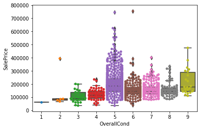

```python
sns.swarmplot(x=df_train["OverallCond"], y=df_train["SalePrice"])
sns.boxplot(x=df_train["OverallCond"], y=df_train["SalePrice"])
```

En nuestro caso tenemos un número grande de observaciones y probablemente es mejor usar el diagrama de violín para ver la distribución de las variables.

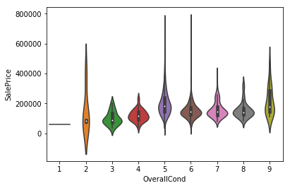

```python
sns.violinplot(x=df_train["OverallCond"], y=df_train["SalePrice"])
```

### Diagrama de dispersión

El diagrama de dispersión muestra la relación de dos variables en dos dimensiones. Cada punto representa una observación, y la posición en los ejes horitzontal y vertical representa el valor de las dos variables para aquella observación. Es un diagrama muy útil para estudiar la relación entre dos variables.

Mostramos la relación entre el precio de venda y los metros cuadrados de una vivienda. Como es de esperar, vemos una clara correlación entre las dos variables.

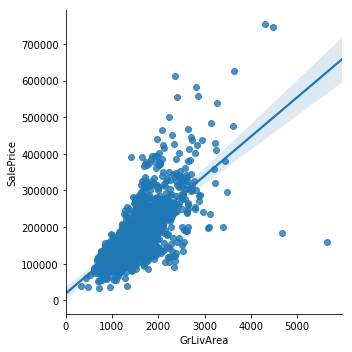

```python
sns.lmplot(x="GrLivArea", y="SalePrice", data=df_train, fit_reg=True, legend=False)
```

Podemos añadirle una tercera dimensión usando colores para codificar otra variable. En este caso, añadiremos la variable categórica `OverallQual` que corresponde a la calificación del habitaje y la mostraremos con un código de colores.

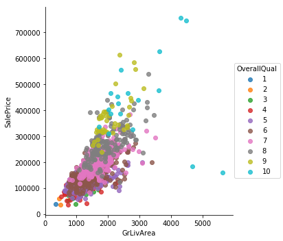

```python
sns.lmplot(x="GrLivArea", y="SalePrice", data=df_train, fit_reg=False, hue="OverallQual", legend=True)
```

La librería `Seaborn` nos permite crear visualizaciones más complejas, y añadirle un histograma para cada eje. A la vez, nos calcula el coeficiente de correlació de Pearson y el p-valor de la medida de correlación.

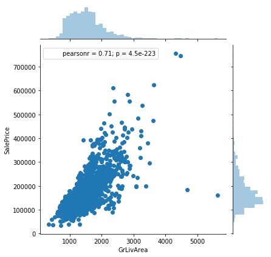

```python
sns.jointplot(x="GrLivArea", y="SalePrice", data=df_train, kind='scatter')
```

Si el hecho de tener muchas observaciones nos esconde la densidad de éstas, podemos usar un `hexbin plot`, que nos divide la cuadrícula en hexágonos y nos codifica con un color más intenso donde tenemos más densidad de observaciones.

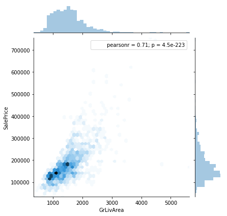

```python
sns.jointplot(x="GrLivArea", y="SalePrice", data=df_train, kind='hex')
```

### Mapa de calor

El mapa de calor es una representación gráfica de los datos donde los valors de una matriz són representados con colores. Es útil para representar visualmente una matriz numérica de datos.

En el siguiente ejemplo, calcularemos la correlación entre diversas variables del conjunto de datos y la mostraremos visualmente con un mapa de calor.

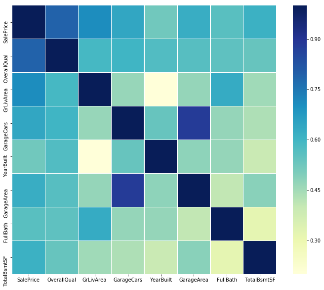

```python
corrmat = df_train.corr(method='spearman')
k = 8 #number of variables for heatmap
cols = corrmat.nlargest(k, 'SalePrice')['SalePrice'].index
cm = np.corrcoef(df_train[cols].values.T)
f, ax = plt.subplots(figsize=(12, 10))
sns.heatmap(cm, ax=ax, cmap="YlGnBu", linewidths=0.1, yticklabels=cols.values, xticklabels=cols.values)
```

## Conclusión

En esta actividad hemos visto algunas de las visualizaciones más comunes y ejemplos de cómo implementarlas en las librerías `Matplotlib` y `Seaborn`. La clave para una buena visualización de los datos es tener claro qué gráfico escoger y por qué, dependiendo de la naturaleza de los datos, y después saber escoger la herramienta para hacerlo posible.

## Bibliografía

Keim, D. A., Mansmann, F., Schneidewind, J., Thomas, J., & Ziegler, H. (2008). Visual analytics: Scope and challenges. In Visual data mining (pp. 76-90). Springer, Berlin, Heidelberg.

Minguillón, J. (2017). Anàlisi visual de dades: conceptes bàsics i eines. Item: revista de biblioteconomia i documentació, 2(63).